# World Coronavirus

**Coronavirus data research**

This Document is an analysis of data for Covid-19 in every country.

A snippet of the dataset is here it includes the country, median age, cases per million, diabetes prevalence, rate of coronavirus (past 5 days), gdp per capita and population density :

```python
import pandas as pd
# reads a file that has the countrys data in it
coron_data = pd.read_csv('refined_corona_data.txt')
# prints out first five values
print(coron_data.head(5))
```

```
   first_country  median  case_per_mill  diabetes_prev      rate        gdp  \
0   Saudi Arabia    31.9       1178.094          17.72   1820.75  49045.411
1  United States    38.3       4072.221          10.79  22736.00  54225.446
2         Canada    41.4       1854.187           7.37   1264.75  44017.591
3      Australia    37.9        272.472           5.07     13.00  44648.710
4          Benin    18.8         26.313           0.99     44.75   2064.236

   pop_density
0       15.322
1       35.608
2        4.037
3        3.202
4       99.110
```

First i will investigate the relationship between a countrys median age and the amount of cases they have per million.

```python
first_analysis = (coron_data[['median','case_per_mill']])
```

[output not shown]

```
<function matplotlib.pyplot.show(*args, **kw)>
```

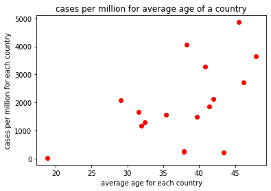

```python
import matplotlib.pyplot as plt
import pandas as pd
x = coron_data['median']
y = coron_data['case_per_mill']
plt.plot([x],[y] , 'ro')
plt.title("cases per million for average age of a country")
plt.xlabel("average age for each country")
plt.ylabel("cases per million for each country")
plt.show
```

The linregress function gives the regression between the two variables.

```python
from scipy.stats import linregress

linregress(x, y)
```

```
LinregressResult(slope=101.6508731469529, intercept=-1910.0648228634846, rvalue=0.5229055210514241, pvalue=0.03126085785478174, stderr=42.783955372982575)
```

The r value = 0.5229 This gives evidence for a moderate positive linear relationship between the average age of a country and cases per million.

Hypothesis test for Zero correlation at 5% significance:

H(o):ρ = 0 H(I):ρ > 0

Sample size: 17 Significance: 5% Critical value: 0.4124 r value > Critical value 0.5229 > 0.4124 The r value is larger than the critical value

There is evidence, at the 5% level of significance that there is a correlation between the cases per million and average age of the country. This means that the higher the age of a country higher the amount of cases per million.

There might be other factors including the amount of testing the correct diagnosis of patients and even dishonesty of certain governments which has been alleged.